# (PSL) Latent Dirichlet Allocation Model

import numpy as np import pandas as pd import matplotlib.pyplot as plt

from wordcloud import WordCloud

import nltk from nltk.corpus import stopwords from nltk.tokenize import RegexpTokenizer from nltk.stem.snowball import SnowballStemmer

import gensim.corpora as corpora from gensim.models import LdaModel, TfidfModel

nltk.download('punkt') nltk.download('stopwords')

Download [JSS_papers.json]

```python
JSS_papers = pd.read_json("JSS_papers.json")
JSS_papers.iloc[0]
```

```
title          A Diagnostic to Assess the Fit of a Variogram ...
creator                                            Barry, Ronald
subject                                                       []
description    The fit of a variogram model to spatially-dist...
publisher                  Foundation for Open Access Statistics
contributor                                                   []
date                                         1996-08-16 00:00:00
type           [info:eu-repo/semantics/article, info:eu-repo/...
format                                                  [PB, SP]
identifier     [https://www.jstatsoft.org/index.php/jss/artic...
source         [Journal of Statistical Software; Vol. 1 (1997...
language                                                     eng
relation       [https://www.jstatsoft.org/index.php/jss/artic...
coverage                                                      []
rights                           Copyright (c) 1996 Ronald Barry
Name: 0, dtype: object
```

```python
print(JSS_papers["date"].min())
print(JSS_papers["date"].max())
```

```
1996-08-16 00:00:00
2023-05-08 00:00:00
```

## Use the `nltk` and `gensim` packages to transform the data to a corpus.

When transforming data to a corpus, we apply the following steps: terms of length less than 3 and the stop words, punctuation, numbers are removed; terms are then stemmed.

```python
des = JSS_papers["description"]

# RegEx for words with length > 3
tokenizer = RegexpTokenizer(r'\b[a-zA-Z]{3,}\b')
tokenized_des = [tokenizer.tokenize(s) for s in des]

# remove stop words
stop_words = stopwords.words('english')
tokenized_des = [[w for w in s if w not in stop_words] for s in tokenized_des]

# stemming the words
stemmer = SnowballStemmer("english")
tokenized_des = [[stemmer.stem(w) for w in s] for s in tokenized_des]

# create corpus
dct_des = corpora.Dictionary(tokenized_des)
corpus_des = [dct_des.doc2bow(line) for line in tokenized_des]
```

## Use TF-IDF (term frequency-inverse document frequency) to select the vocabulary.

Goal: filter terms with low frequences as well as those occurring in many documents. We only include terms whose TF-IDF values are at least 0.1, which is a bit more than the median and ensures that the very frequent terms are omitted.

```python
tfidf_model = TfidfModel(corpus_des)  # fit tf-idf model

low_value_words = []
for bow in corpus_des:
    low_value_words += [id for id, value in tfidf_model[bow] if value < 0.1]
```

```python
[dct_des.get(low_value_words[i]) for i in range(20)]
```

```
['allow',
 'assess',
 'data',
 'determin',
 'distribut',
 'find',
 'general',
 'help',
 'identifi',
 'introduc',
 'measur',
 'model',
 'often',
 'qualiti',
 'set',
 'simul',
 'spatial',
 'specif',
 'the',
 'use']
```

```python
# filter words from the dictionary and the corpus
dct_des.filter_tokens(bad_ids=low_value_words)
corpus_des = [dct_des.doc2bow(line) for line in tokenized_des]
```

## Fit an LDA model with 30 topics

The output is an LDA object, from which we obtain a term frequency vector (over all words) for each of the 30 topic, and other summaries from this topic model.

```python
lda = LdaModel(corpus_des, num_topics=30, id2word=dct_des, passes=10, iterations=500)
```

```python
# 5 most frequent terms for each top
# may also use lda.show_topics()
top_terms = []
for i in range(30):
    tmp_terms = lda.get_topic_terms(i, topn=5)
    top_terms.append([dct_des.get(tmp_terms[j][0]) for j in range(5)])

top_terms
```

```
[['ergm', 'statnet', 'lisp', 'hte', 'bsl'],
 ['ergm', 'mds', 'gee', 'graphlet', 'qls'],
 ['wavelet', 'jag', 'sur', 'grts', 'sdr'],
 ['contigu', 'angular', 'cfust', 'tidi', 'toler'],
 ['conform', 'lavaan', 'pfim', 'regcompon', 'optimum'],
 ['mediat', 'tgui', 'itemset', 'arf', 'satellit'],
 ['biplot', 'boost', 'clickstream', 'smale', 'pomp'],
 ['squarem', 'mother', 'segreg', 'breast', 'bss'],
 ['envelop', 'rcaptur', 'scalar', 'dif', 'ball'],
 ['shrinkag', 'degrad', 'hyperspectr', 'rubi', 'equilibrium'],
 ['scala', 'mlwin', 'programmat', 'matchit', 'stress'],
 ['moult', 'roc', 'eda', 'inequ', 'epidem'],
 ['indelec', 'fuzzi', 'wtp', 'vista', 'pdfs'],
 ['sunflow', 'mida', 'jasp', 'isotropi', 'glimmps'],
 ['haplotyp', 'micromap', 'mitisem', 'simecol', 'ilm'],
 ['mantel', 'stan', 'vista', 'surveil', 'pcovr'],
 ['irt', 'nonstationari', 'fdr', 'mondrian', 'clue'],
 ['julia', 'obliqu', 'gas', 'oja', 'driver'],
 ['gam', 'rasch', 'fluoresc', 'irt', 'qgam'],
 ['circular', 'heteroskedast', 'blang', 'fechnerian', 'mixlow'],
 ['bart', 'mst', 'emmixuskew', 'sgmcmc', 'sandwich'],
 ['socr', 'client', 'cgi', 'teigen', 'hydra'],
 ['abc', 'dtw', 'abcpi', 'manifest', 'incdtw'],
 ['lisp', 'tsp', 'themat', 'impur', 'multibug'],
 ['fmri', 'factori', 'ses', 'wave', 'cuda'],
 ['inla', 'smoother', 'interfer', 'pst', 'gpu'],
 ['anim', 'poli', 'redistrict', 'tumor', 'bard'],
 ['changepoint', 'recurr', 'pop', 'gee', 'pilot'],
 ['mediat', 'smc', 'nimbl', 'lisp', 'github'],
 ['resist', 'antimicrobi', 'bilinear', 'arima', 'ssa']]
```

## Generate word clouds

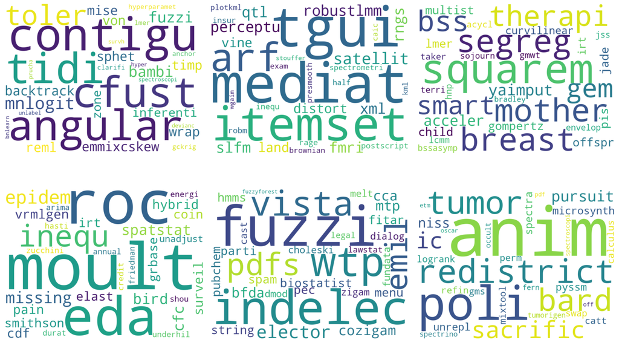

```python
# Wordcloud for individual topics
topic_id = [3, 5, 7, 11, 12, 26]

fig, axes = plt.subplots(nrows=2, ncols=3, figsize=(15, 10))
for i, idx in enumerate(topic_id):
    tmp_cloud = WordCloud(width=800, height=600, background_color="white")
    tmp_cloud.fit_words(dict(lda.show_topic(idx, 30)))
    axes[i // 3, i % 3].imshow(tmp_cloud)
    axes[i // 3, i % 3].axis('off')

fig.tight_layout()
```